# Rosado_Avery_Tuesday

Avery Rosado

4/25/2020

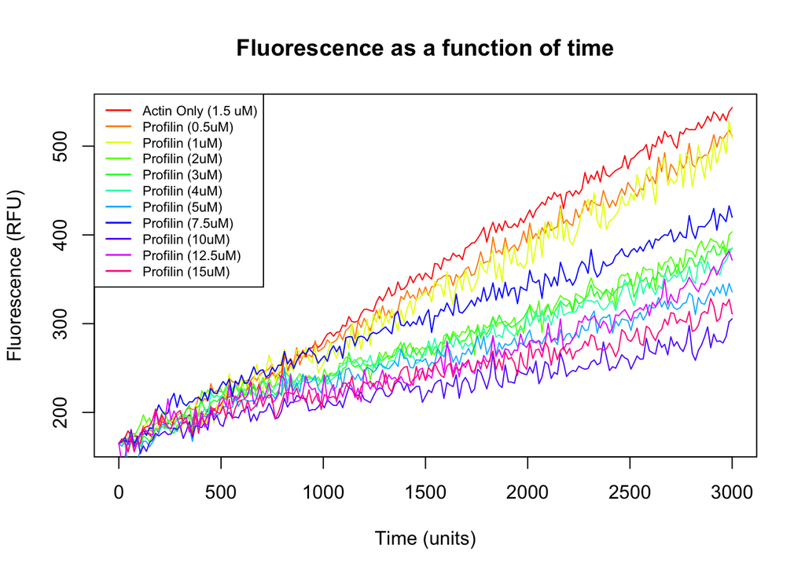

```r
rm=(list=ls())   #Global Env't cleared out
#Read in data file
Profilin=read.csv("/Users/airosado/Desktop/CLASSES/First\ Year/BIOS\ 20186/20186_Lab4/Pre_Lab/Profilin_AssemblyCurves.csv")  #Data Frame

# Assign columns to variables
time <- Profilin$Time
actin <- Profilin$ActinOnly
p0.5 <- Profilin$p0_5uM
p1 <- Profilin$p1uM
p2 <- Profilin$p2uM
p3 <- Profilin$p3uM
p4 <- Profilin$p4uM
p5 <- Profilin$p5uM
p7.5 <- Profilin$p7_5uM
p10 <- Profilin$p10uM
p12.5 <- Profilin$p12_5uM
p15 <- Profilin$p15uM

cl=rainbow(11)

plot(time, actin, xlab= "Time (units)", ylab="Fluorescence (RFU)", main="Fluorescence as a function of time", col=cl[1], type="l")
lines(time, p0.5, col=cl[2], type="l")
lines(time, p1, col=cl[3], type="l")
lines(time, p2, col=cl[4], type="l")
lines(time, p3, col=cl[5], type="l")
lines(time, p4, col=cl[6], type="l")
lines(time, p5, col=cl[7], type="l")
lines(time, p7.5, col=cl[8], type="l")
lines(time, p10, col=cl[9], type="l")
lines(time, p12.5, col=cl[10],type="l")
lines(time, p15, col=cl[11], type="l")

legend("topleft", legend=c("Actin Only (1.5 uM)", "Profilin (0.5uM)", "Profilin (1uM)", "Profilin (2uM)", "Profilin (3uM)", "Profilin (4uM)", "Profilin (5uM)", "Profilin (7.5uM)", "Profilin (10uM)", "Profilin (12.5uM)", "Profilin (15uM)"), col=cl, lwd=1.5, cex=0.7)
```

The plot above illustrates that, as the concentration of profilin increases in a system, fluorescence decreases proportionally; the Actin Only system has the highest fluorescence, and 15uM profilin system the lower. This trend is true broadly, but there are clear exceptions, such as 10uM profilin, which has the lowest levels of fluorescence of any profilin, and 7.5uM profilin, which has greater levels of fluorescence than several of the lower lower concentration variants.

Furthermore, for all systems, regardless of profilin concentration, as time goes on, fluorescence increases at a somewhat steady rate. Given negative proportionality between fluorescence and profilin concentration, and the positive relationship between actin expression and fluorescence, it can be concluded that, generally, assembly curves of actin are reduced in slope as profilin concentration increases.

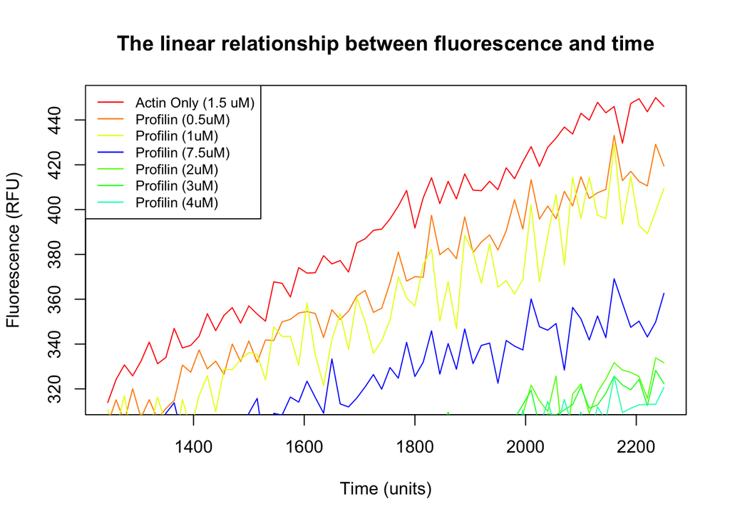

```r
# Data extraction in a specific time region; A look into the elongation phase of actin assembly

st <- 84
end <- 151

cl=rainbow(11)

#Resctrict for arrays
plot(time[st:end], actin[st:end], col=cl[1], xlab="Time (units)", ylab="Fluorescence (RFU)", main="The linear relationship between fluorescence and time", type="l")
lines(time[st:end], p0.5[st:end], col=cl[2], type="l")
lines(time[st:end], p1[st:end], col=cl[3], type="l")
lines(time[st:end], p7.5[st:end], col=cl[8], type="l")
lines(time[st:end], p2[st:end], col=cl[4], type="l")
lines(time[st:end], p3[st:end], col=cl[5], type="l")
lines(time[st:end], p4[st:end], col=cl[6], type="l")
lines(time[st:end], p5[st:end], col=cl[7], type="l")
lines(time[st:end], p10[st:end], col=cl[9], type="l")
lines(time[st:end], p12.5[st:end], col=cl[10], type="l")
lines(time[st:end], p15[st:end], col=cl[11], type="l")

legend("topleft", legend=c("Actin Only (1.5 uM)", "Profilin (0.5uM)", "Profilin (1uM)", "Profilin (7.5uM)", "Profilin (2uM)", "Profilin (3uM)", "Profilin (4uM)"), col=c(cl[1], cl[2], cl[3], cl[8], cl[4], cl[5], cl[6]), lwd=1.2, cex=0.8)
```

It can also be noted that, for concentration’s 2uM, 3uM, and 4uM, there is a great deal of intersections and coincidences, revealing similarities in the lengths of their respective nucleation phases.

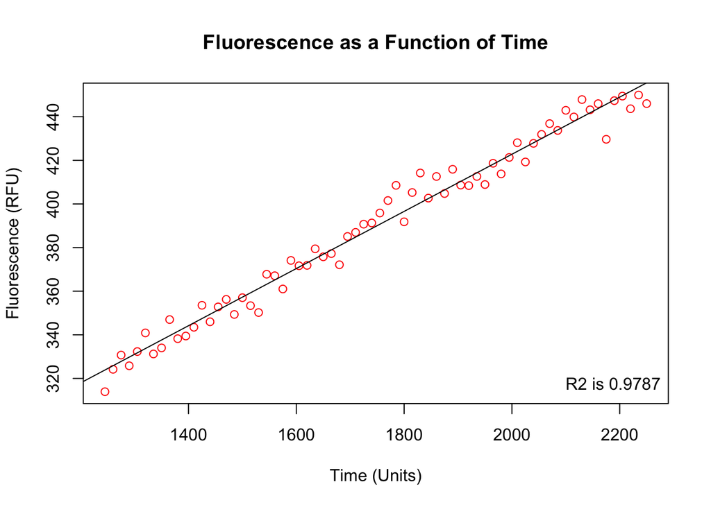

```r
###
profilin_slope <- vector()
actin <- Profilin$ActinOnly

cl=rainbow(11)

fit <- lm(actin[84:151] ~ time[84:151])
intercept <- fit$coefficients[1]
slope <- fit$coefficients[2]
R2 <- summary(fit)$r.squared
profilin_slope[1] <- slope
plot(time[84:151], actin[84:151], xlab = "Time (Units)", ylab = "Fluorescence (RFU)", main= "Fluorescence as a Function of Time", type = "p", col=cl[1])
abline(fit)
legend("bottomright", bty="n", legend=paste("R2 is", format(summary(fit)$r.squared, digits=4)))
```

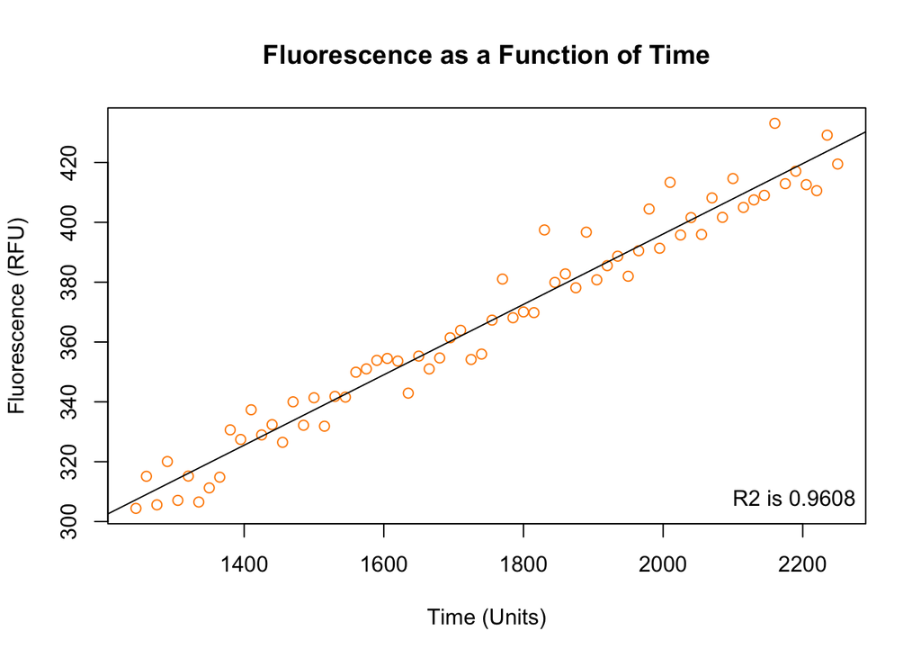

```r
fit <- lm(p0.5[84:151] ~ time[84:151])
intercept <- fit$coefficients[1]
slope <- fit$coefficients[2]
R2 <- summary(fit)$r.squared
profilin_slope[2] <- slope
plot(time[84:151], p0.5[84:151], xlab = "Time (Units)", ylab = "Fluorescence (RFU)", main= "Fluorescence as a Function of Time", type = "p", col=cl[2])
abline(fit)
legend("bottomright", bty="n", legend=paste("R2 is", format(summary(fit)$r.squared, digits=4)))
```

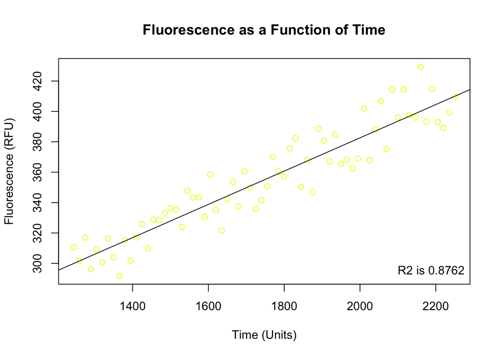

```r
fit <- lm(p1[84:151] ~ time[84:151])
intercept <- fit$coefficients[1]
slope <- fit$coefficients[2]
R2 <- summary(fit)$r.squared
profilin_slope[3] <- slope
plot(time[84:151], p1[84:151], xlab = "Time (Units)", ylab = "Fluorescence (RFU)", main= "Fluorescence as a Function of Time", type = "p", col=cl[3])
abline(fit)
legend("bottomright", bty="n", legend=paste("R2 is", format(summary(fit)$r.squared, digits=4)))
```

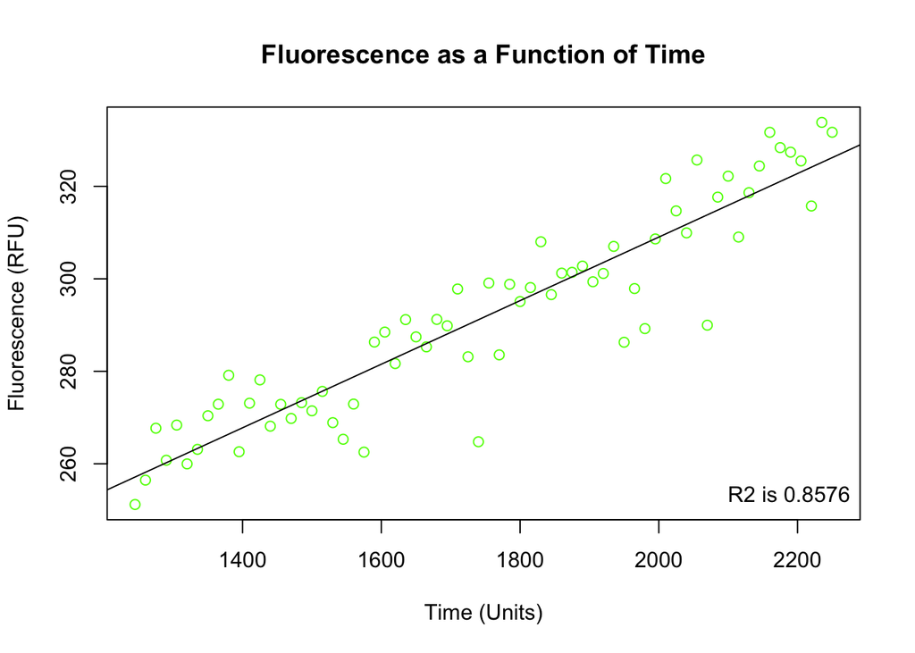

```r
fit <- lm(p2[84:151] ~ time[84:151])
intercept <- fit$coefficients[1]
slope <- fit$coefficients[2]
R2 <- summary(fit)$r.squared
profilin_slope[4] <- slope
plot(time[84:151], p2[84:151], xlab = "Time (Units)", ylab = "Fluorescence (RFU)", main= "Fluorescence as a Function of Time", type = "p", col=cl[4])
abline(fit)
legend("bottomright", bty="n", legend=paste("R2 is", format(summary(fit)$r.squared, digits=4)))
```

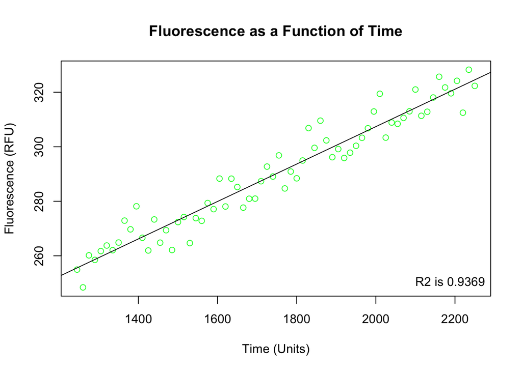

```r
fit <- lm(p3[84:151] ~ time[84:151])
intercept <- fit$coefficients[1]
slope <- fit$coefficients[2]
R2 <- summary(fit)$r.squared
profilin_slope[5] <- slope
plot(time[84:151], p3[84:151], xlab = "Time (Units)", ylab = "Fluorescence (RFU)", main= "Fluorescence as a Function of Time", type = "p", col=cl[5])
abline(fit)
legend("bottomright", bty="n", legend=paste("R2 is", format(summary(fit)$r.squared, digits=4)))
```

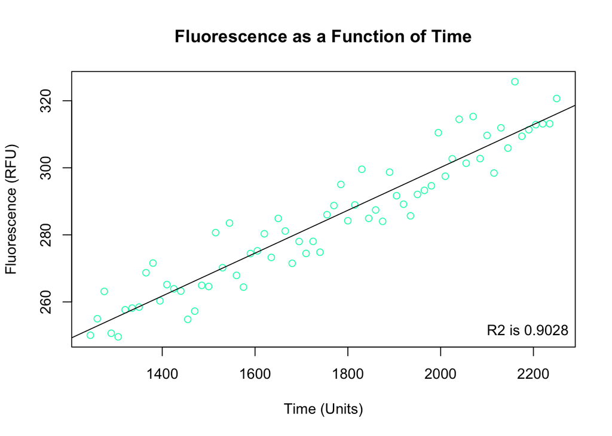

```r
fit <- lm(p4[84:151] ~ time[84:151])
intercept <- fit$coefficients[1]
slope <- fit$coefficients[2]
R2 <- summary(fit)$r.squared
profilin_slope[6] <- slope
plot(time[84:151], p4[84:151], xlab = "Time (Units)", ylab = "Fluorescence (RFU)", main= "Fluorescence as a Function of Time", type = "p", col=cl[6])
abline(fit)
legend("bottomright", bty="n", legend=paste("R2 is", format(summary(fit)$r.squared, digits=4)))
```

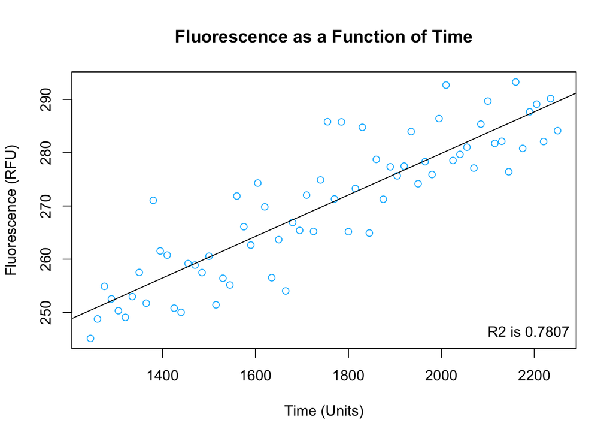

```r
fit <- lm(p5[84:151] ~ time[84:151])
intercept <- fit$coefficients[1]
slope <- fit$coefficients[2]
R2 <- summary(fit)$r.squared
profilin_slope[7] <- slope
plot(time[84:151], p5[84:151], xlab = "Time (Units)", ylab = "Fluorescence (RFU)", main= "Fluorescence as a Function of Time", type = "p", col=cl[7])
abline(fit)
legend("bottomright", bty="n", legend=paste("R2 is", format(summary(fit)$r.squared, digits=4)))
```

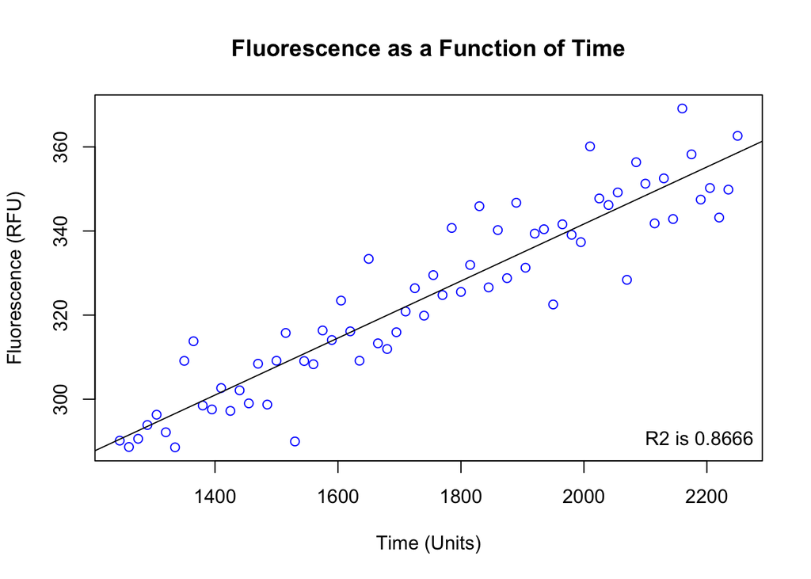

```r
fit <- lm(p7.5[84:151] ~ time[84:151])
intercept <- fit$coefficients[1]
slope <- fit$coefficients[2]
R2 <- summary(fit)$r.squared
profilin_slope[8] <- slope
plot(time[84:151], p7.5[84:151], xlab = "Time (Units)", ylab = "Fluorescence (RFU)", main= "Fluorescence as a Function of Time", type = "p", col=cl[8])
abline(fit)
legend("bottomright", bty="n", legend=paste("R2 is", format(summary(fit)$r.squared, digits=4)))
```

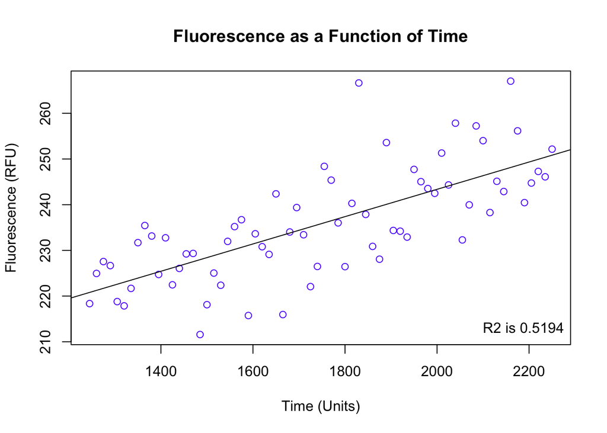

```r
fit <- lm(p10[84:151] ~ time[84:151])
intercept <- fit$coefficients[1]
slope <- fit$coefficients[2]
R2 <- summary(fit)$r.squared
profilin_slope[9] <- slope
plot(time[84:151], p10[84:151], xlab = "Time (Units)", ylab = "Fluorescence (RFU)", main= "Fluorescence as a Function of Time", type = "p", col=cl[9])
abline(fit)
legend("bottomright", bty="n", legend=paste("R2 is", format(summary(fit)$r.squared, digits=4)))
```

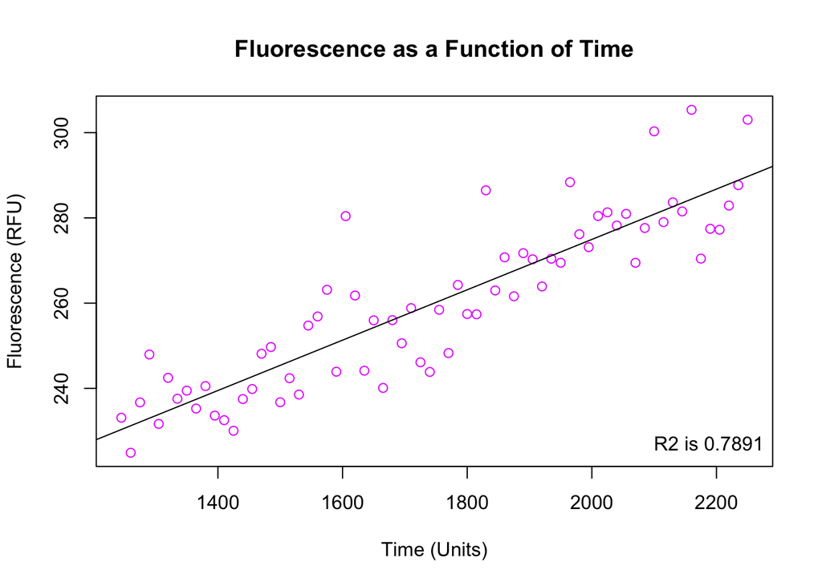

```r
fit <- lm(p12.5[84:151] ~ time[84:151])
intercept <- fit$coefficients[1]
slope <- fit$coefficients[2]
R2 <- summary(fit)$r.squared
profilin_slope[10] <- slope
plot(time[84:151], p12.5[84:151], xlab = "Time (Units)", ylab = "Fluorescence (RFU)", main= "Fluorescence as a Function of Time", type = "p", col=cl[10])
abline(fit)
legend("bottomright", bty="n", legend=paste("R2 is", format(summary(fit)$r.squared, digits=4)))
```

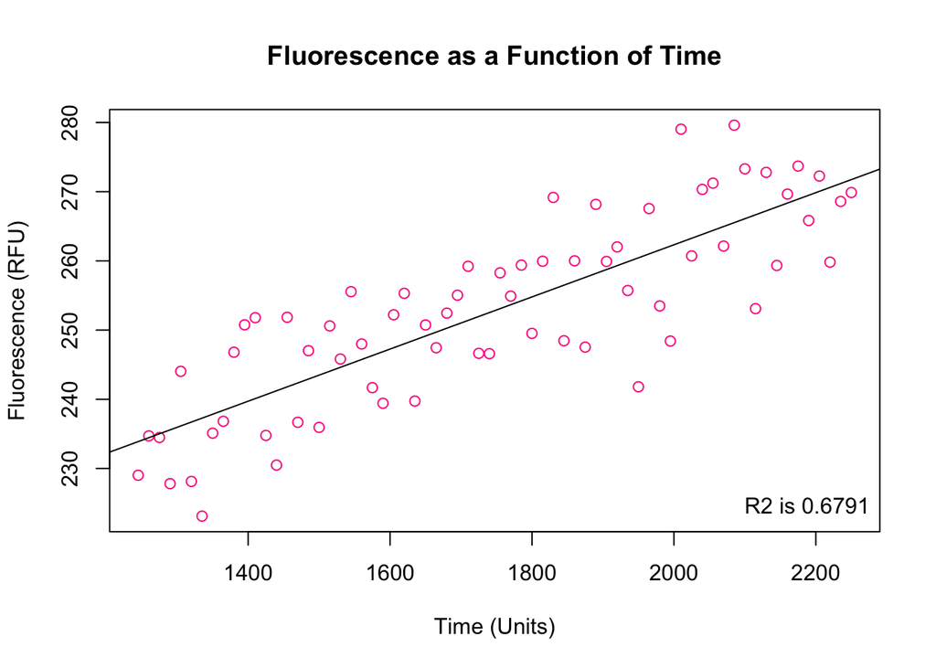

```r
fit <- lm(p15[84:151] ~ time[84:151])
intercept <- fit$coefficients[1]
slope <- fit$coefficients[2]
R2 <- summary(fit)$r.squared
profilin_slope[11] <- slope
plot(time[84:151], p15[84:151], xlab = "Time (Units)", ylab = "Fluorescence (RFU)", main= "Fluorescence as a Function of Time", type = "p", col=cl[11])
abline(fit)
legend("bottomright", bty="n", legend=paste("R2 is", format(summary(fit)$r.squared, digits=4)))
```

```r
profilin_slope <- c(profilin_slope[1], profilin_slope[2], profilin_slope[3], profilin_slope[4], profilin_slope[5], profilin_slope[6], profilin_slope[7], profilin_slope[8], profilin_slope[9], profilin_slope[10], profilin_slope[11])

# profilin_slope1 <- array(vector1)
```

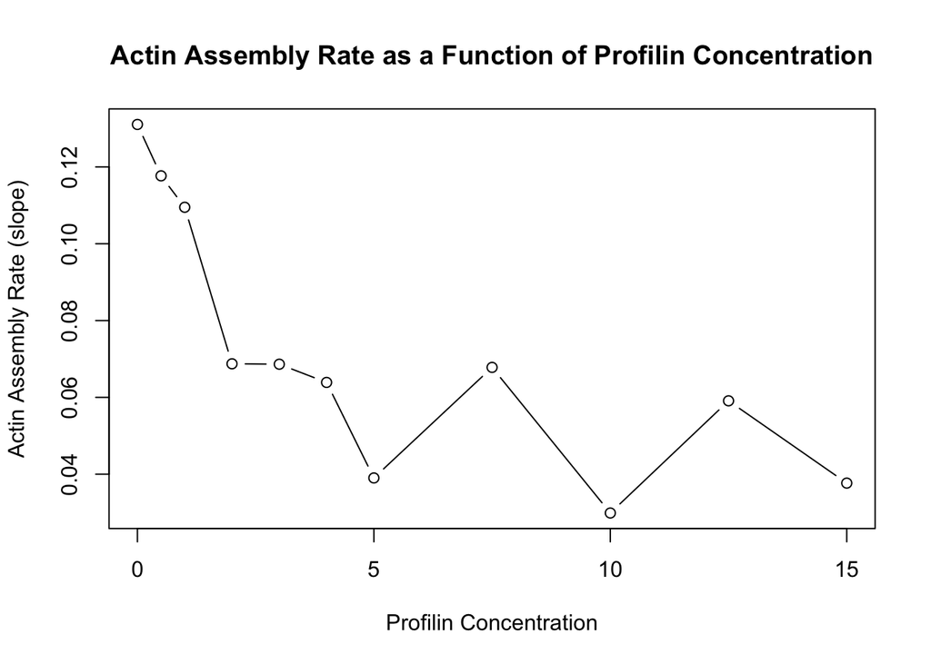

```r
profilin <- c(0, 0.5, 1, 2, 3, 4, 5, 7.5, 10, 12.5, 15)

plot(profilin[1:11], profilin_slope[1:11], xlab="Profilin Concentration", ylab="Actin Assembly Rate (slope)", main = "Actin Assembly Rate as a Function of Profilin Concentration", type = "b")
```

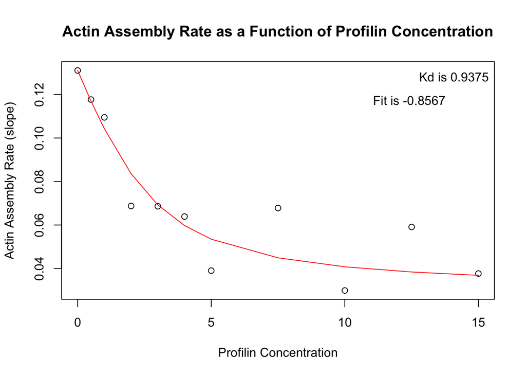

```r
# non linear fit (assembly vs. profilin concentration) ; find the best kd that fits the data with least error between the nonlinear fit and the experimental data
# plot the data and the fit, extract a Kd. profilin for G-actin



actin <- Profilin$ActinOnly

### Nonlinear Least Squares, Syntax
kdfit <- nls(profilin_slope~(max(profilin_slope)+(min(profilin_slope)-max(profilin_slope))*(((kd+2.5+profilin)-sqrt((kd+2.5+profilin)^2-4*2.5*profilin))/(2*2.5))), start=list(kd=1)) # (nls = nonlinear least squares)

p <- coef(summary(kdfit))  # grab info from solver
kd_est <- p[1]   # first coeff in solution of nonlinear model is kd
goodfit <- cor(profilin, predict(kdfit))   # for goodness of nonlinear model with predicated parameters


plot(profilin, profilin_slope, xlab="Profilin Concentration", ylab="Actin Assembly Rate (slope)", main = "Actin Assembly Rate as a Function of Profilin Concentration")
lines(profilin, predict(kdfit), col="red")
legend("topright", bty="n", legend=paste("Kd is", format(kd_est, digits = 4)))
legend("topright", bty="n", inset=0.1, legend=paste("Fit is", format(goodfit, digits=4)))
```

(Q. 4) The graph illustrates a downward trend in the rate of actin assembly as the concentration of profilin increases. The Kd of profilin for g-actin is 0.9375, which is relatively high, meaning that profilin has a strong affinity for g-actin. Inside the cell, profilin binds g-actin and prevents nucleation, hereby preventing filament assembly. This is accurately represented by this graph.

```r
At <- 100   # total actin in the cell
Pt <- 100   # total profilin in the cell
Kd <- 0.9375    # dissociation constant determined earlier

# Pt. 1
AP <- ((At + Pt + Kd) - sqrt(((At + Pt + Kd)^2)-4*(At*Pt)))/2    # AP is the fraction of actin bound by profilin, calculated via the quadratic equation
print(AP)
```

```
## [1] 90.77495
```

```r
# Pt. 2
percentbound <-(AP/At)*100   #Percentage of G-actin bound with profilin
print(percentbound)
```

```
## [1] 90.77495
```

The code above returns the following: Concentration of G-actin bound with profilin = 90.77495 Percent G-actin bound with profilin = 90.77495%

There are equal amounts of profilin and actin in this scenario. The set of results illustrates a very high concentration of intracellular G-actin monomer being bound to profilin and a high percentage of total actin being bound to profilin; both values are identical. Thus, when the total amount of actin is equal to the total amount of profilin, a high portion of the total actin in the cell consists of G-actin bound to profilin. This means that the cell will produce a small amount of long filaments, as the profilin will act to prevent nucleation in upwards of 90% of G-actin monomers that would otherwise be available for polymerization.

```r
At1 <- 50
Pt1 <- 100
Kd <- 0.9375

# Pt. 1
AP1 <- ((At1 + Pt1 +Kd) - sqrt(((At1 + Pt1 + Kd)^2)-4*(At1*Pt1)))/2
print(AP1)
```

```
## [1] 49.09581
```

```r
# Pt. 2
percentbound1 <-(AP1/At1)*100
print(percentbound1)
```

```
## [1] 98.19161
```

The code above returns the following: Concentration of G-actin bound with profilin = 49.09581 Percent G-actin bound with profilin = 98.19161

Part V, Q7

Typical Cell: 50uM G-actin ; 50 uM F-actin ; (100uM total actin) ; 100uM profilin

These values do make sense considering the determined affinity of profilin for G-actin (0.9375); the matching values for G-actin and F-actin follow the logic of the expressions used to arrive at Kd, and of the observed relationships between these values and the expression of long vs short filaments based on the expression of the nucleation-suppressant profilin.

Profilin binds G-actin and prevents nucleation. Thus, as the concentration of profilin increases in the cell, the rate of actin polymerization decreases. A concentration of around 50 for G-actin bound to profilin facilitates the nucleation and F-actin regulation necessary for cellular functions.